# AssignmentW6-57363645-0227

```python
from sklearn.feature_selection import SelectKBest   #the "SelectKBest" removes all but the top K highest scoring features
from sklearn.feature_selection import chi2,f_classif
from matplotlib import pyplot as plt
# these are two selection criterias
# the "f_classif" Computes the ANOVA F-value for the provided sample.
# the "chi2" computes chi-squared stats between each non-negative feature and class.
import pandas as pd
```

## Assignment - Due in Week 8¶

### 1. use f_classif as your evaluation measurement and redo the feature selection in Univariate feature selection. what does "f_classif" represent? Is this a filter model or wrapper model? (10 points).

```python
iris = pd.read_csv('iris.txt', header = None)
iris.columns=['sepal-L','sepal-W','petal-L','petal-W','class']
iris
```

|  | sepal-L | sepal-W | petal-L | petal-W | class |
| --- | --- | --- | --- | --- | --- |
| 0 | 5.1 | 3.5 | 1.4 | 0.2 | Iris-setosa |
| 1 | 4.9 | 3.0 | 1.4 | 0.2 | Iris-setosa |
| 2 | 4.7 | 3.2 | 1.3 | 0.2 | Iris-setosa |
| 3 | 4.6 | 3.1 | 1.5 | 0.2 | Iris-setosa |
| 4 | 5.0 | 3.6 | 1.4 | 0.2 | Iris-setosa |
| ... | ... | ... | ... | ... | ... |
| 145 | 6.7 | 3.0 | 5.2 | 2.3 | Iris-virginica |
| 146 | 6.3 | 2.5 | 5.0 | 1.9 | Iris-virginica |
| 147 | 6.5 | 3.0 | 5.2 | 2.0 | Iris-virginica |
| 148 | 6.2 | 3.4 | 5.4 | 2.3 | Iris-virginica |
| 149 | 5.9 | 3.0 | 5.1 | 1.8 | Iris-virginica |

150 rows × 5 columns

```python
features = ['sepal-L','sepal-W','petal-L','petal-W']
target = ['class']
X = iris[features]
y = iris[target]
X = X.values
y = y.values.ravel()
display(X)
```

[output not shown]

[output cut: 95 more lines]

```
       [7.7, 3. , 6.1, 2.3],
       [6.3, 3.4, 5.6, 2.4],
       [6.4, 3.1, 5.5, 1.8],
       [6. , 3. , 4.8, 1.8],
       [6.9, 3.1, 5.4, 2.1],
       [6.7, 3.1, 5.6, 2.4],
       [6.9, 3.1, 5.1, 2.3],
       [5.8, 2.7, 5.1, 1.9],
       [6.8, 3.2, 5.9, 2.3],
       [6.7, 3.3, 5.7, 2.5],
       [6.7, 3. , 5.2, 2.3],
       [6.3, 2.5, 5. , 1.9],
       [6.5, 3. , 5.2, 2. ],
       [6.2, 3.4, 5.4, 2.3],
       [5.9, 3. , 5.1, 1.8]])
```

```python
my_model = SelectKBest(f_classif,k=2)
X_new=my_model.fit_transform(X,y)
X_new.shape
```

```
(150, 2)
```

```python
display(X_new[0:5,])
```

```
array([[1.4, 0.2],
       [1.4, 0.2],
       [1.3, 0.2],
       [1.5, 0.2],
       [1.4, 0.2]])
```

r: The f_classif represents the F-test applied on each feature with the target variable. By calculating and comparing the ratio of variance between them, the model selects the top k feature as the final feature set. Thus it is a filter model.

### 2. Explain the differences among univariate feature selection, SelectFromModel method, and PCA. (10 points)

r: i. univariate feature selection: filter model selects features based on their individual relationship with target variable, normally according to a statistic metric. It is simple and fast, but ignore the interactions between features.

ii. SelectFromModel: wrapper model uses machine learning method to process the training data. It can capture the interactions between features but may get into overfitting.

iii.PCA: dimensionality reduction technique which is usually useful for reducing the dimensionality of data and removing noise and redundancy in the features. It emphasizes the relationship between features thus ignores their relationship with target variable, which may lead to a less interpretable features.

### 3. Read documentation of "SequentialFeatureSelector" and use it to select the top TWO features. What is the mechnism of this tool? What are these two optimal features? (40 points)¶

### document: https://scikit-learn.org/stable/modules/generated/sklearn.feature_selection.SequentialFeatureSelector.html

```python
from sklearn.feature_selection import SequentialFeatureSelector
from sklearn.neighbors import KNeighborsClassifier
```

```python
knn = KNeighborsClassifier()
sfs = SequentialFeatureSelector(knn,n_features_to_select=2)
sfs.fit(X,y)
print(sfs.get_support())
X_new = sfs.transform(X)
print(X_new.shape)
```

```
[False False  True  True]
(150, 2)
```

```python
print(X_new[1:5,])
```

```
[[1.4 0.2]
 [1.3 0.2]
 [1.5 0.2]
 [1.4 0.2]]
```

r: SFS starts with an empty set of selected features and add or remove a feature at one time, it stops when the classifier algorithm makes the most improvement. sfs.get_support() prints False False True True, follow the position we know petal-length and petal-width is chosen.

### 4. Find a new dataset and use ONE of the templates to do feature selection or reduction. Reduce the data dimension to Two. Please scatter plot your optimal feature set and interpret. (40 points)¶

```python
from sklearn.datasets import load_wine
import seaborn as sns
from sklearn.decomposition import PCA
wine = load_wine()

dfw = pd.DataFrame(wine.data, columns=wine.feature_names)
dfw['target'] = wine.target
```

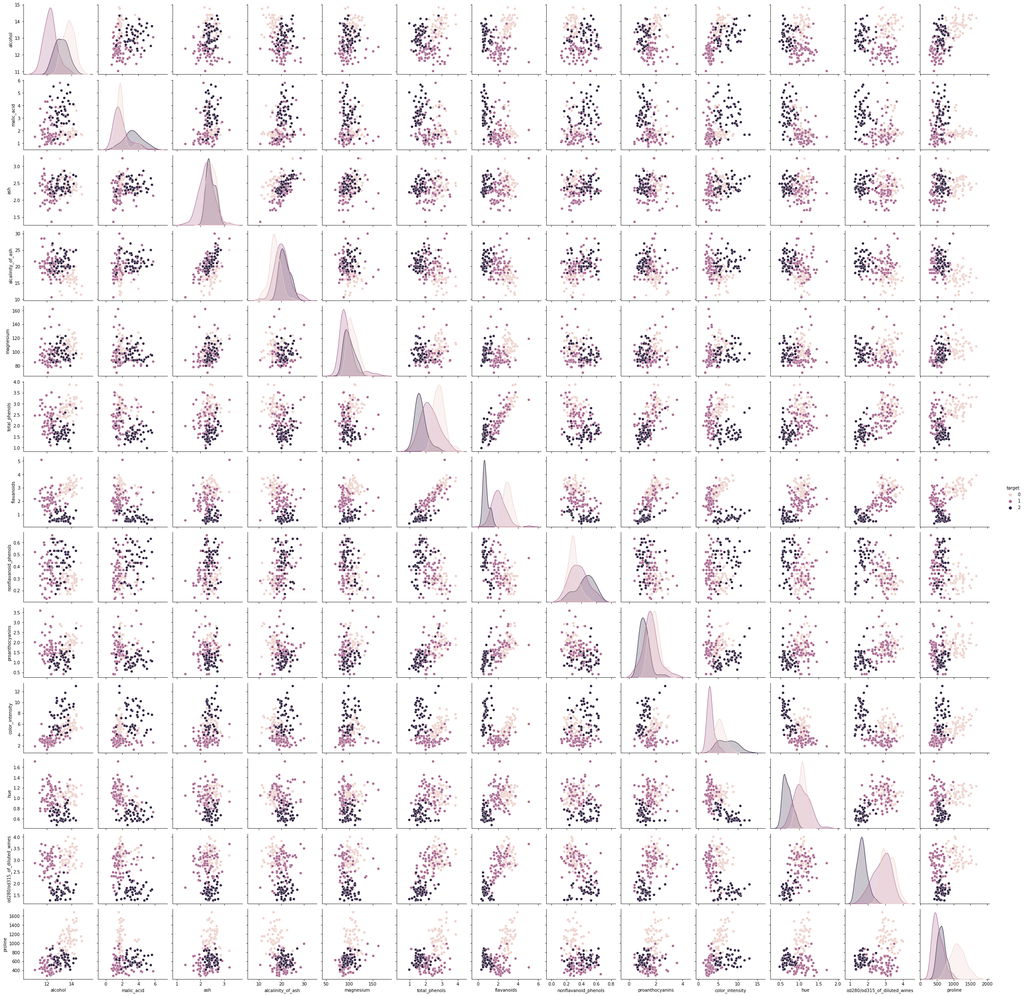

```python
sns.pairplot(dfw, hue="target")
```

```python
pca = PCA(n_components=2)
z=pca.fit_transform(dfw[wine.feature_names])
```

```python
display(z[:5,:])
```

```
array([[ 3.18562979e+02,  2.14921307e+01],
       [ 3.03097420e+02, -5.36471768e+00],
       [ 4.38061133e+02, -6.53730945e+00],
       [ 7.33240139e+02,  1.92729032e-01],
       [-1.15714285e+01,  1.84899946e+01]])
```

```python
dfw['z1']=z[:,0]
dfw['z2']=z[:,1]
```

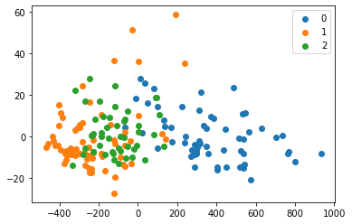

```python
groups = dfw.groupby("target")
for name, group in groups:
    plt.scatter(group['z1'],group['z2'], marker="o", label=name)
plt.legend()
plt.show()
```

r: we can see different types of wines are still diffcult to seperate. In the PCA processing, we may lost some important features which should effect the judgement of wine types only by working with other features. But to some certain extent, we find a wrapper feature "z1" can classify the "0 wine" well.